# Homework 8: Variable Selection

DATA 627 - Statistical Machine Learning, Fall 2025

Author

Ana Paula Miranda

Published

October 16, 2025

# 1 Multicollinearity

(a) Perform the following commands in R to generate 100 sets of data for variables $x_1$ and $x_2$ so they are correlated:

````markdown
```{r}
#| label: create-data
#| include: true
#| eval: true
set.seed(123)
n <- 100
x1 <- runif(n)
x2 <- 0.5 * x1 + rnorm(n) / 10
y <- 2 + 3 * x1 + 0.2 * x2 + rnorm(n)
```
````

The last line corresponds to creating a linear model in which $y$ is a function of $x_1$ and $x_2$.

- What are the *true* regression coefficients?
- Write out the *true* linear model as $y$ as a function of $\bf{x}$.

**The equation is:**

$$y = 2 + 3X_1 + 0.2X_2 + \epsilon$$
Where $\epsilon \approx N(0, 1)$ - the random error.

(b) Given we know the true relationship,…

- Use the formula for the variance of a Continuous Uniform Random Variable, $\text{Var}(x_1) = \frac{1}{12}(b-a)^2$, to calculate the *true* variance of $x_1$ as a number.

```r
var_x1 <- (1 / 12) * (1 - 0)^2
var_x1
```

```
[1] 0.08333333
```

- Since $x_2$ is the sum of two random variables of known variances, calculate its *true* variance as a number.

```r
Var_Z <- 1
var_x2 <- ((0.5)^2) * var_x1 + ((1/10)^2) * Var_Z
var_x2
```

```
[1] 0.03083333
```

- Use the definition of Covariance to calculate the *true* covariance of $x_1$ and $x_2$ as a number.

```r
Cov_x1_x2 <- 0.5 * var_x1
Cov_x1_x2
```

```
[1] 0.04166667
```

- Use the formula for Correlation, $\text{Corr}(x_1,x_2) =\frac{\text{Cov}(x_1,x_2)}{\text{std}(x_1)\text{std}(x_2)}$ to calculate the *true* correlation between $x_1$ and $x_2$ as a number.

```r
corr_x1_x2 <- Cov_x1_x2 / (sqrt(var_x1) * sqrt(var_x2))
corr_x1_x2
```

```
[1] 0.8219949
```

- Use the R function `corr()` to calculate the *sample* correlation between $x_1$ and $x_2$?

```r
cor(x1, x2)
```

```
[1] 0.823406
```

- Create a scatter plot displaying the relationship between $x_1$ and $x_2$.

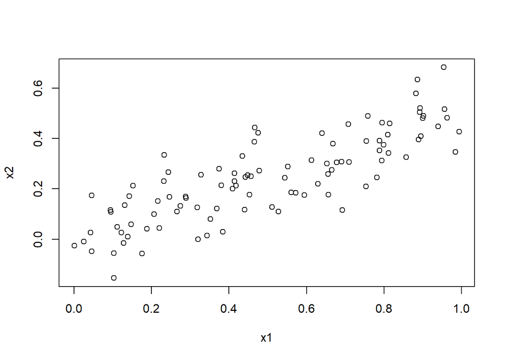

```r
plot(x1, x2)
```

(c) Using this data, fit a least squares regression to predict `y` using `x1` and `x2`.

- Interpret the results.

```r
library(tidyverse)
df <- data.frame(x1, x2, y)
glimpse(df)
```

```
Rows: 100
Columns: 3
$ x1 <dbl> 0.28757752, 0.78830514, 0.40897692, 0.88301740, 0.94046728, 0.04555…
$ x2 <dbl> 0.16912061, 0.39129789, 0.20020142, 0.57836893, 0.44765654, 0.17442…
$ y  <dbl> 3.684296, 5.212217, 3.599174, 3.756349, 4.791481, 1.891159, 4.16914…
```

```r
mlr_out <- lm(y ~ x1 + x2, df)
summary(mlr_out)
```

```
Call:
lm(formula = y ~ x1 + x2, data = df)

Residuals:
    Min      1Q  Median      3Q     Max
-1.3894 -0.7111 -0.2090  0.5479  3.1526

Coefficients:
            Estimate Std. Error t value Pr(>|t|)
(Intercept)   2.0698     0.1902  10.884  < 2e-16 ***
x1            3.3066     0.5843   5.659 1.54e-07 ***
x2           -0.6510     0.9798  -0.664    0.508
---
Signif. codes:  0 '***' 0.001 '**' 0.01 '*' 0.05 '.' 0.1 ' ' 1

Residual standard error: 0.9402 on 97 degrees of freedom
Multiple R-squared:  0.4569,    Adjusted R-squared:  0.4457
F-statistic:  40.8 on 2 and 97 DF,  p-value: 1.385e-13
```

- What is the model equation with $\hat{\beta}_0, \hat{\beta1},$ and $\hat{\beta}_2$?
- The estimated regression function is:

$$\hat{y} = 2.0698 + 3.3066(x_1) - 0.6510(x_2)$$

- Compare the true $\beta_0, \beta_1,$ and $\beta_2$ and estimated parameters for the model.
- The estimated $\beta_0$ and $\beta_1$ are very similar to the true parameters. However, $\beta_2$ is larger and negative compared with the true value. Small deviations are expected due to random noise and multicolinearity from x1 and x2.
  - $\beta_0$: 2.0698 vs. 2
  - $\beta_1$: 3.3066 vs. 3
  - $\beta_2$: 0.2 vs. -0.65.
- Comment on the standard errors of the estimated parameters.
- The estimated standard error for x1 is 0.5843 versus 0.2886751 for true value. For x2 it is 0.9798 versus 0.1755942 for true value. The estimated coefficients have larger standard errors.
- Is there sufficient evidence to reject the null hypothesis $H0: \beta_1 = 0$?

For x1, the p-value is 1.54e-07, which is much smaller than any considered significance level (0.05, 0.01, 0.001). This means the probability of observing such a strong effect if the true coefficient were 0 is extremely low.

Yes, there is strong evidence to reject, the null hypothesis. Therefore, x1 has a statistically significant effect on y, even after controlling for x2.

- How about the null hypothesis $H0: \beta_2 = 0$?

Therefore, there is not enough evidence to reject the null hypothesis. In other words, x2 does not appear to be a statistically significant predictor of y once x1 is already in the model.

(d) Now fit a reduced model using least squares regression to predict `y` using only `x1`. Comment on your results, especially the standard error for the coefficient estimate. Can you reject the null hypothesis $H0: \beta_1 = 0$?

```r
mlr_out_red <- lm(y ~ x1, df)
summary(mlr_out_red)
```

```
Call:
lm(formula = y ~ x1, data = df)

Residuals:
    Min      1Q  Median      3Q     Max
-1.4059 -0.6843 -0.1832  0.5068  3.2150

Coefficients:
            Estimate Std. Error t value Pr(>|t|)
(Intercept)   2.0704     0.1896  10.919  < 2e-16 ***
x1            2.9870     0.3306   9.035  1.5e-14 ***
---
Signif. codes:  0 '***' 0.001 '**' 0.01 '*' 0.05 '.' 0.1 ' ' 1

Residual standard error: 0.9375 on 98 degrees of freedom
Multiple R-squared:  0.4544,    Adjusted R-squared:  0.4489
F-statistic: 81.63 on 1 and 98 DF,  p-value: 1.503e-14
```

Now, for x1 the p-value is 1.5e-14, which is highly statistically significant at any level (0.05, 0.01, 0.001). There is strong evidence to reject the null hypothesis, $H0: \beta_1 = 0$. Therefore, x1 has a statistically significant effect on y.

The standard error is 0.3306 and it decreased compared to when x2 was in the model. Now it’s very close to the true standard deviation for x1.

(e) Now fit a least squares regression to predict `y` using only `x2`. Comment on your results, especially the standard error for the coefficient estimate. Can you reject the null hypothesis $H0: \beta_2 = 0$?

```r
mlr_out_red2 <- lm(y ~ x2, df)
summary(mlr_out_red2)
```

```
Call:
lm(formula = y ~ x2, data = df)

Residuals:
    Min      1Q  Median      3Q     Max
-2.2468 -0.7449 -0.1429  0.6582  3.6690

Coefficients:
            Estimate Std. Error t value Pr(>|t|)
(Intercept)   2.6048     0.1893  13.757  < 2e-16 ***
x2            3.9148     0.6380   6.136 1.79e-08 ***
---
Signif. codes:  0 '***' 0.001 '**' 0.01 '*' 0.05 '.' 0.1 ' ' 1

Residual standard error: 1.079 on 98 degrees of freedom
Multiple R-squared:  0.2776,    Adjusted R-squared:  0.2702
F-statistic: 37.66 on 1 and 98 DF,  p-value: 1.792e-08
```

Now, for x2 the p-value is 1.79e-08, which is highly statistically significant at any level (0.05, 0.01, 0.001). There is strong evidence to reject the null hypothesis, $H0: \beta_2 = 0$. Therefore, x2 has a statistically significant effect on y.

The standard error is 0.6380 and it decreased compared to when x1 was in the model. It’s still larger than the true standard deviation for x2.

(f) Do the results obtained in (c) - (e) contradict each other? Explain your answer.

The results may seem contradictory at first, but they actually reveal the effect of multicollinearity in regression analysis.

- x2 looks strong on its own because it is taking signals from x1.
- x2 is weak when x1 is present, because x1 already explains most of what x2 could explain.

(g) Now suppose we obtain one additional observation, which was unfortunately mismeasured. Use the following R code.

Re-fit the linear models from (c) to (e) using this new data. What effect does this new observation have on each of the models? How do the slopes from all the considered models change given the newly added data point?

```r
x1p <- c(x1, 0.1)
x2p <- c(x2, 0.8)
yp <- c(y, 6)
```

```r
df2 <- data.frame(x1p, x2p, yp)

mlr_out_p <- lm(yp ~ x1p + x2p, df2)
summary(mlr_out_p)
```

```
Call:
lm(formula = yp ~ x1p + x2p, data = df2)

Residuals:
    Min      1Q  Median      3Q     Max
-1.5979 -0.6704 -0.1529  0.4796  3.3329

Coefficients:
            Estimate Std. Error t value Pr(>|t|)
(Intercept)   2.1587     0.1984  10.881  < 2e-16 ***
x1p           2.1773     0.5075   4.290 4.19e-05 ***
x2p           1.3959     0.8167   1.709   0.0906 .
---
Signif. codes:  0 '***' 0.001 '**' 0.01 '*' 0.05 '.' 0.1 ' ' 1

Residual standard error: 0.9901 on 98 degrees of freedom
Multiple R-squared:  0.4134,    Adjusted R-squared:  0.4014
F-statistic: 34.53 on 2 and 98 DF,  p-value: 4.457e-12
```

```r
lm(yp ~ x1p, df2)
```

```
Call:
lm(formula = yp ~ x1p, data = df2)

Coefficients:
(Intercept)          x1p
      2.193        2.812
```

```r
lm(yp ~ x2p, df2)
```

```
Call:
lm(formula = yp ~ x2p, data = df2)

Coefficients:
(Intercept)          x2p
      2.596        3.961
```

(h) Examine standard errors of estimated $\beta$s in (c), (d), and (e)? Which models produce more stable estimates with smaller confidence intervals, and therefore more reliable estimates of the parameters?

```r
confint(mlr_out)
```

```
                2.5 %   97.5 %
(Intercept)  1.692405 2.447256
x1           2.146985 4.466238
x2          -2.595577 1.293672
```

```r
confint(mlr_out_red)
```

```
               2.5 %   97.5 %
(Intercept) 1.694118 2.446710
x1          2.330913 3.643054
```

```r
confint(mlr_out_red2)
```

```
               2.5 %   97.5 %
(Intercept) 2.229017 2.980495
x2          2.648813 5.180840
```

In conclusion, for better interpretability and stable parameter estimates, model in (d) is the most reliable in this case.

(i) Compute both VIF for the full model by hand using the results from question (b) and then using full model compared to the reduced models with R. Relate them to your answer to question (h).

```r
VIF_true <- 1 / (1 - (0.823406)^2)
VIF_true
```

```
[1] 3.105565
```

```r
library(car)
vif(mlr_out)
```

```
      x1       x2
3.105565 3.105565
```

The full model shows variance inflation of approximately 3x for both x1 and x2, which is due to the strong correlation between x1 and x2, making the coefficient estimates less reliable.

(j) The two variance inflation factors in the previous question are close to each other and `car::vif()` provides the same value. Would this always be the case? Generalize to any linear regression model with $p = 2$ independent variables, either showing or disproving that $\text{VIF}_1 = \text{VIF}_2$.

- Yes, in any multiple regression model with exactly two independent variables (p = 2) we would get that: $\text{VIF}_1 = \text{VIF}_2$.
- This is always true because the $R^2$ values for regressing x1 ~ x2 is the same as when regressing x2 ~ x1.

(k) Can your conclusion be extended to $p = 3$? Explain.

- However, for models with more than two predictors (p > 2), VIFs are not expected to be equal, because each predictor is regressed on all the others and multicollinearity structure varies by each one of the predictors.

# 2 College Applications

Predict the number of applications received based on the other variables in the College data set in {ISLR2}.

- Use `set.seed(123)` where appropriate and 50% split where appropriate.

(a) Find the best least squares regression model, using adjusted R2, BIC, and Cp criteria, as well as the stepwise variable selection. Choose a model as your best model and justify your choice.

```r
library(ISLR2)
library(leaps)
library(tidyverse)
data(College)
glimpse(College)
```

```
Rows: 777
Columns: 18
$ Private     <fct> Yes, Yes, Yes, Yes, Yes, Yes, Yes, Yes, Yes, Yes, Yes, Yes…
$ Apps        <dbl> 1660, 2186, 1428, 417, 193, 587, 353, 1899, 1038, 582, 173…
$ Accept      <dbl> 1232, 1924, 1097, 349, 146, 479, 340, 1720, 839, 498, 1425…
$ Enroll      <dbl> 721, 512, 336, 137, 55, 158, 103, 489, 227, 172, 472, 484,…
$ Top10perc   <dbl> 23, 16, 22, 60, 16, 38, 17, 37, 30, 21, 37, 44, 38, 44, 23…
$ Top25perc   <dbl> 52, 29, 50, 89, 44, 62, 45, 68, 63, 44, 75, 77, 64, 73, 46…
$ F.Undergrad <dbl> 2885, 2683, 1036, 510, 249, 678, 416, 1594, 973, 799, 1830…
$ P.Undergrad <dbl> 537, 1227, 99, 63, 869, 41, 230, 32, 306, 78, 110, 44, 638…
$ Outstate    <dbl> 7440, 12280, 11250, 12960, 7560, 13500, 13290, 13868, 1559…
$ Room.Board  <dbl> 3300, 6450, 3750, 5450, 4120, 3335, 5720, 4826, 4400, 3380…
$ Books       <dbl> 450, 750, 400, 450, 800, 500, 500, 450, 300, 660, 500, 400…
$ Personal    <dbl> 2200, 1500, 1165, 875, 1500, 675, 1500, 850, 500, 1800, 60…
$ PhD         <dbl> 70, 29, 53, 92, 76, 67, 90, 89, 79, 40, 82, 73, 60, 79, 36…
$ Terminal    <dbl> 78, 30, 66, 97, 72, 73, 93, 100, 84, 41, 88, 91, 84, 87, 6…
$ S.F.Ratio   <dbl> 18.1, 12.2, 12.9, 7.7, 11.9, 9.4, 11.5, 13.7, 11.3, 11.5, …
$ perc.alumni <dbl> 12, 16, 30, 37, 2, 11, 26, 37, 23, 15, 31, 41, 21, 32, 26,…
$ Expend      <dbl> 7041, 10527, 8735, 19016, 10922, 9727, 8861, 11487, 11644,…
$ Grad.Rate   <dbl> 60, 56, 54, 59, 15, 55, 63, 73, 80, 52, 73, 76, 74, 68, 55…
```

```r
rownames(College) <- NULL
```

```r
n <- nrow(College)
set.seed(123)
Z <- sample(1:n, n/2)
train <- College[Z, ]
test <- College[-Z, ]
```

```r
mlr_college_full <- regsubsets(Apps ~ ., data = train, nvmax = 17)
mlr_college_summary <- summary(mlr_college_full)
names(mlr_college_summary)
```

```
[1] "which"  "rsq"    "rss"    "adjr2"  "cp"     "bic"    "outmat" "obj"
```

- Best Model based on adjusted R2:

```r
which.max(mlr_college_summary$adjr2)
```

```
[1] 11
```

```r
mlr_college_summary$which[11,][-1] # drop the intercept term
```

```
 PrivateYes      Accept      Enroll   Top10perc   Top25perc F.Undergrad
       TRUE        TRUE       FALSE        TRUE        TRUE       FALSE
P.Undergrad    Outstate  Room.Board       Books    Personal         PhD
      FALSE        TRUE        TRUE       FALSE        TRUE        TRUE
   Terminal   S.F.Ratio perc.alumni      Expend   Grad.Rate
      FALSE       FALSE        TRUE        TRUE        TRUE
```

```r
lm_adjr2 <- lm(Apps ~ Private + Accept + Top10perc + Top25perc + Outstate +
               Room.Board + Personal + PhD + perc.alumni + Expend + Grad.Rate,
               data = train)
summary(lm_adjr2)
```

```
Call:
lm(formula = Apps ~ Private + Accept + Top10perc + Top25perc +
    Outstate + Room.Board + Personal + PhD + perc.alumni + Expend +
    Grad.Rate, data = train)

Residuals:
    Min      1Q  Median      3Q     Max
-2590.9  -459.7   -55.0   316.9  6036.5

Coefficients:
              Estimate Std. Error t value Pr(>|t|)
(Intercept) -244.05963  360.66396  -0.677  0.49902
PrivateYes  -773.63945  182.65512  -4.236 2.87e-05 ***
Accept         1.33357    0.03340  39.922  < 2e-16 ***
Top10perc     37.91154    6.86930   5.519 6.36e-08 ***
Top25perc     -9.02635    5.52462  -1.634  0.10313
Outstate      -0.05470    0.02392  -2.287  0.02276 *
Room.Board     0.16647    0.05859   2.841  0.00474 **
Personal      -0.09406    0.08231  -1.143  0.25382
PhD          -10.39546    4.19496  -2.478  0.01365 *
perc.alumni   -9.66023    5.32286  -1.815  0.07034 .
Expend         0.08233    0.01720   4.785 2.46e-06 ***
Grad.Rate     11.45425    3.87757   2.954  0.00333 **
---
Signif. codes:  0 '***' 0.001 '**' 0.01 '*' 0.05 '.' 0.1 ' ' 1

Residual standard error: 959.5 on 376 degrees of freedom
Multiple R-squared:  0.9155,    Adjusted R-squared:  0.913
F-statistic: 370.3 on 11 and 376 DF,  p-value: < 2.2e-16
```

```r
pred_best11 <- predict(lm_adjr2, newdata = test)
mean((test$Apps - pred_best11)^2)
```

```
[1] 1384997
```

- Best Model based on BIC:

```r
round(mlr_college_summary$bic,0)
```

```
 [1] -761 -872 -879 -895 -897 -900 -898 -898 -895 -892 -887 -882 -876 -870 -865
[16] -859 -853
```

```r
which.max(mlr_college_summary$bic) # The worst by BIC
```

```
[1] 1
```

```r
which.min(mlr_college_summary$bic) # The best by BIC
```

```
[1] 6
```

```r
mlr_college_summary$which[6,][mlr_college_summary$which[6,] == TRUE][-1]
```

```
PrivateYes     Accept  Top10perc Room.Board   Terminal     Expend
      TRUE       TRUE       TRUE       TRUE       TRUE       TRUE
```

```r
lm_bic <- lm(Apps ~ Private + Accept + Top10perc + Room.Board + Terminal + Expend,
             data = train)
summary(lm_bic)
```

```
Call:
lm(formula = Apps ~ Private + Accept + Top10perc + Room.Board +
    Terminal + Expend, data = train)

Residuals:
    Min      1Q  Median      3Q     Max
-2301.3  -490.9   -72.0   283.2  6338.9

Coefficients:
              Estimate Std. Error t value Pr(>|t|)
(Intercept)   51.82552  343.22158   0.151 0.880058
PrivateYes  -898.77388  153.58382  -5.852 1.05e-08 ***
Accept         1.34277    0.03295  40.757  < 2e-16 ***
Top10perc     28.48115    4.15138   6.861 2.78e-11 ***
Room.Board     0.16531    0.05711   2.895 0.004013 **
Terminal     -16.13390    4.64016  -3.477 0.000566 ***
Expend         0.07198    0.01565   4.600 5.77e-06 ***
---
Signif. codes:  0 '***' 0.001 '**' 0.01 '*' 0.05 '.' 0.1 ' ' 1

Residual standard error: 974.7 on 381 degrees of freedom
Multiple R-squared:  0.9116,    Adjusted R-squared:  0.9102
F-statistic: 655.1 on 6 and 381 DF,  p-value: < 2.2e-16
```

```r
pred_best_bic <- predict(lm_bic, newdata = test)

mean((test$Apps - pred_best_bic)^2)
```

```
[1] 1410582
```

- Best Model based on CP:

```r
round(mlr_college_summary$cp, 2)
```

```
 [1] 215.16  61.21  48.17  26.99  20.69  14.15  12.05   8.09   7.21   6.50
[11]   7.21   8.54  10.35  12.23  14.03  16.00  18.00
```

```r
which.max(abs(mlr_college_summary$cp - 1:17)) # The worst by Cp - underfit so high bias.
```

```
[1] 1
```

```r
which.min(abs(mlr_college_summary$cp - 1:17)) # The best by Cp
```

```
[1] 16
```

```r
names(mlr_college_summary$which[16,][mlr_college_summary$which[16,] == TRUE])[-1]
```

```
 [1] "PrivateYes"  "Accept"      "Enroll"      "Top10perc"   "Top25perc"
 [6] "F.Undergrad" "Outstate"    "Room.Board"  "Books"       "Personal"
[11] "PhD"         "Terminal"    "S.F.Ratio"   "perc.alumni" "Expend"
[16] "Grad.Rate"
```

```r
lm_cp <- lm(Apps ~ Private + Accept + Enroll + Top10perc + Top25perc + F.Undergrad +
              Outstate + Room.Board + Books + Personal + PhD + Terminal + S.F.Ratio +
              perc.alumni + Expend + Grad.Rate,
               data = train)
summary(lm_cp)
```

```
Call:
lm(formula = Apps ~ Private + Accept + Enroll + Top10perc + Top25perc +
    F.Undergrad + Outstate + Room.Board + Books + Personal +
    PhD + Terminal + S.F.Ratio + perc.alumni + Expend + Grad.Rate,
    data = train)

Residuals:
    Min      1Q  Median      3Q     Max
-2625.0  -472.5   -63.2   319.1  6044.6

Coefficients:
              Estimate Std. Error t value Pr(>|t|)
(Intercept)   78.78257  580.39912   0.136  0.89210
PrivateYes  -814.08553  199.66011  -4.077 5.58e-05 ***
Accept         1.35055    0.07225  18.692  < 2e-16 ***
Enroll        -0.14316    0.25893  -0.553  0.58068
Top10perc     37.88223    7.06285   5.364 1.44e-07 ***
Top25perc     -8.69812    5.62860  -1.545  0.12312
F.Undergrad    0.02048    0.04333   0.473  0.63683
Outstate      -0.05351    0.02464  -2.172  0.03052 *
Room.Board     0.17052    0.06054   2.817  0.00511 **
Books          0.05302    0.31775   0.167  0.86756
Personal      -0.09901    0.08564  -1.156  0.24838
PhD           -6.51422    6.20311  -1.050  0.29433
Terminal      -6.17071    7.13424  -0.865  0.38763
S.F.Ratio     -8.69662   19.49805  -0.446  0.65584
perc.alumni   -8.90046    5.52107  -1.612  0.10779
Expend         0.07938    0.01949   4.074 5.66e-05 ***
Grad.Rate     11.18040    3.91890   2.853  0.00457 **
---
Signif. codes:  0 '***' 0.001 '**' 0.01 '*' 0.05 '.' 0.1 ' ' 1

Residual standard error: 964.4 on 371 degrees of freedom
Multiple R-squared:  0.9158,    Adjusted R-squared:  0.9121
F-statistic: 252.1 on 16 and 371 DF,  p-value: < 2.2e-16
```

```r
pred_best_cp <- predict(lm_cp, newdata = test)

mean((test$Apps - pred_best_cp)^2)
```

```
[1] 1373113
```

- Best Model based on Stepwise Forward Selection:

```r
reg_full <- lm(Apps ~ ., data = train)
reg_null <- lm(Apps ~ 1, data = train)
```

```r
step_outf <- step(reg_null,
                 scope = list(lower = reg_null, upper = reg_full),
                 method = "forward",
                 trace = 0)
summary(step_outf)
```

```
Call:
lm(formula = Apps ~ Accept + Top10perc + Expend + Private + Terminal +
    Room.Board + Outstate + Grad.Rate + Top25perc + perc.alumni,
    data = train)

Residuals:
    Min      1Q  Median      3Q     Max
-2576.8  -462.3   -57.4   298.3  6110.1

Coefficients:
              Estimate Std. Error t value Pr(>|t|)
(Intercept) -273.94713  371.06732  -0.738  0.46081
Accept         1.33194    0.03341  39.865  < 2e-16 ***
Top10perc     36.25335    6.89273   5.260 2.42e-07 ***
Expend         0.07998    0.01713   4.668 4.23e-06 ***
PrivateYes  -777.75988  183.09697  -4.248 2.72e-05 ***
Terminal     -11.95819    4.81763  -2.482  0.01349 *
Room.Board     0.17969    0.05906   3.043  0.00251 **
Outstate      -0.04878    0.02392  -2.039  0.04216 *
Grad.Rate     11.34021    3.84465   2.950  0.00338 **
Top25perc     -8.59416    5.58542  -1.539  0.12472
perc.alumni   -7.95834    5.27519  -1.509  0.13223
---
Signif. codes:  0 '***' 0.001 '**' 0.01 '*' 0.05 '.' 0.1 ' ' 1

Residual standard error: 960.6 on 377 degrees of freedom
Multiple R-squared:  0.9151,    Adjusted R-squared:  0.9128
F-statistic: 406.2 on 10 and 377 DF,  p-value: < 2.2e-16
```

```r
pred_step_outf <- predict(step_outf, newdata = test)

mean((test$Apps - pred_step_outf)^2)
```

```
[1] 1379139
```

- Best Model based on Stepwise Backward Selection:

```r
step_outb <- step(reg_null,
                 scope = list(lower = reg_null, upper = reg_full),
                 method = "backward",
                 trace = 0)
summary(step_outb)
```

```
Call:
lm(formula = Apps ~ Accept + Top10perc + Expend + Private + Terminal +
    Room.Board + Outstate + Grad.Rate + Top25perc + perc.alumni,
    data = train)

Residuals:
    Min      1Q  Median      3Q     Max
-2576.8  -462.3   -57.4   298.3  6110.1

Coefficients:
              Estimate Std. Error t value Pr(>|t|)
(Intercept) -273.94713  371.06732  -0.738  0.46081
Accept         1.33194    0.03341  39.865  < 2e-16 ***
Top10perc     36.25335    6.89273   5.260 2.42e-07 ***
Expend         0.07998    0.01713   4.668 4.23e-06 ***
PrivateYes  -777.75988  183.09697  -4.248 2.72e-05 ***
Terminal     -11.95819    4.81763  -2.482  0.01349 *
Room.Board     0.17969    0.05906   3.043  0.00251 **
Outstate      -0.04878    0.02392  -2.039  0.04216 *
Grad.Rate     11.34021    3.84465   2.950  0.00338 **
Top25perc     -8.59416    5.58542  -1.539  0.12472
perc.alumni   -7.95834    5.27519  -1.509  0.13223
---
Signif. codes:  0 '***' 0.001 '**' 0.01 '*' 0.05 '.' 0.1 ' ' 1

Residual standard error: 960.6 on 377 degrees of freedom
Multiple R-squared:  0.9151,    Adjusted R-squared:  0.9128
F-statistic: 406.2 on 10 and 377 DF,  p-value: < 2.2e-16
```

```r
pred_step_outb <- predict(step_outb, newdata = test)

mean((test$Apps - pred_step_outb)^2)
```

```
[1] 1379139
```

(b) Evaluate prediction accuracy of your selected model, estimating the prediction mean-squared-error by some cross-validation method.

**Save your results**, because we’ll soon compare them against ridge regression, LASSO, PCR, and PLS.

Prediction performance based on the *test data set* was best for the Cp method and that’s my final selected model.